# MATH 140 Getting Started in RStudio

Hitchman

2022-02-15

Lab 1 provides a general introduction to RStudio and the coding language R, which together form a powerful tool for visualizing and analyzing data. This pre-lab page is meant to give you some practice ahead of time.

**I encourage you to reproduce all of the results on this page in your own RStudio session.**

# Using RStudio

This page assumes you’ve already [oriented yourself in RStudio](https://mphitchman.com/stats/rstudio.html#2_Orient_yourself_in_RStudio).

# How to Input and Import Data

## Input data as a vector

> The `c()` command is used to input an ordered list of values or characters. We call such a list a **vector**.

Here ‘c’ stands for combine, or concatenate. The ‘c’ also helps me remember to separate the entries in the `c()` command with commas.

When entering data with the `c()` command, it is good practice to assign a name to the vector. To assign a name you can either use the symbol `=` or the symbol `<-`, as we do below.

Below, we input a vector of words, giving it the name *name*. I have also defined the vector *height*, which consists of numbers, and the vector *age* consisting of five integers.

```r
name <- c("Dustin","Will","Lucas","Eleven","Mike")
height <- c(61.3, 61.9, 63.8, 62.1, 64.3)
age <- c(12,12,13,11,13)
```

If you run these three lines of code in your own RStudio session, you should see the values ‘age’, ‘height’, and ‘name’ in your Environment tab.

## Create a data frame from vectors

The three vectors above are related. Do you recognize the names as characters from *Stranger Things*? Yes! I’ve also estimated heights for these characters as well as ages (in Season 1). Since the vectors all have the same length (5 elements in each), we can assemble these vectors in a *data frame* with the following command.

```r
st <- data.frame(name,height,age)
```

Try doing this in your own session. The data frame ‘st’ should appear in your Environment tab after running this command. My Environment tab now looks like this:

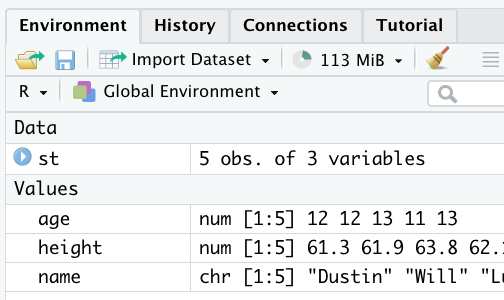

A data frame, also called a *data matrix* is a two-dimensional array such as you would find in an Excel file or Google sheet. In the data frame *st*, each row is a *Stranger Things* character, and we’ve got three pieces of information about each: their name, height, and age. In general, the rows of a data matrix are called *observations*, and the columns give the *variables*. We have more to say about data frames below.

We can view the first $n$ rows of a data frame called `st` with the command `head(st,n)`:

```r
head(st,5)
```

```
##     name height age
## 1 Dustin   61.3  12
## 2   Will   61.9  12
## 3  Lucas   63.8  13
## 4 Eleven   62.1  11
## 5   Mike   64.3  13
```

## Import a .csv data file from the web

The world is awash in data, and a common file type is the .csv file, which stands for *comma separated values*. With RStudio, such data files are at our fingertips! We can import a .csv file from the web using the `read.csv()` command. Inside the parentheses we enter inside quotes the link address to the data set. For instance, the following code imports the file called softball.csv from our course resource page, and it names the data matrix `wildcats` in our RStudio session.

```r
wildcats <- read.csv("https://www.mphitchman.com/stats/data/softball.csv")
```

What does the `wildcats` data set look like? Here’s a look at the first 6 rows:

```r
head(wildcats,6)
```

```
##   Year           Coach  W  L T District NCAA
## 1 1999     Laura Kenow 20 17 0      3rd
## 2 2000     Laura Kenow 24 10 0      4th
## 3 2001     Laura Kenow 24 17 0      2nd
## 4 2002 Jackson Vaughan 21 17 0      3rd
## 5 2003 Jackson Vaughan 27 11 0      2nd
## 6 2004 Jackson Vaughan 37  9 0      1st
```

`wildcats` is our second example of a data frame. Recall, the rows of a data matrix are called *observations*, the columns give the *variables*. In `wildcats` each row is a season, and the variables include the year, the coach, wins, losses, and how well the team did in regionals and nationals.

If you are following along in your own RStudio session, and you should be, you will also see `wildcats` in the Environment tab. If you click on the arrow to the left of `wildcats` you can see information about the variables (columns) in the data matrix. If you click on the word `wildcats` then the data matrix should appear in the upper left pane of your session in spreadsheet form.

## Analyzing a particular column in a data frame

> The general format for specifiying a particular column in a data frame is `(name of data frame)$(name of column)`.  
> For instance, `wildcats$W` will extract the *W* column of the `wildcats` data frame.

To find the average number of wins per season from 1999 to 2020, we can use the `mean()` command on the win column:

```r
mean(wildcats$W)
```

```
## [1] 33.86364
```

The average number of losses per season?

```r
mean(wildcats$L)
```

```
## [1] 9.772727
```

# Descriptive Statistics in RStudio

Here are some common functions we can use to explore and summarize a data set.

| function | description |
| --- | --- |
| `length()` | returns the size of the data set entered in the parentheses |
| `mean()` | returns the mean of the data set |
| `median()` | returns the median |
| `max()` | returns the maximum of the data |
| `min()` | returns the min |
| `sum()` | returns the sum of the data |
| `var()` | returns the variance of the data |
| `sd()` | returns the standard deviation of the data |
| `summary()` | returns 6 statistics: min, Q1, median, mean, Q3, max |
| `fivenum()` | returns the 5 number summary: min Q1 median Q3 max |
| `table()` | returns the frequency of each unique value of the data |

We can apply these functions to a vector, whether it be a column in a data frame, or a stand alone vector:

```r
fivenum(wildcats$W)
```

```
## [1] 12.0 27.0 36.5 39.0 51.0
```

```r
min(height)
```

```
## [1] 61.3
```

The first result above gives the 5 number summary for Linfield wins. A full 25% of the seasons over the 1999-2020 time period saw win totals of at least 39! The second result above gives the minimum value in the height vector we defined at the start of this pre-lab.

How many games did Linfield softball win between 1999 and 2020?

```r
sum(wildcats$W)
```

```
## [1] 745
```

Who has coached Linfield softball during this period?

```r
table(wildcats$Coach)
```

```
##
## Jackson Vaughan     Laura Kenow
##              19               3
```

# Basic data management (very brief sampler)

## Extracting particular elements in a list

```r
x <- c(10,12,14,16,9,13)
x[3] # returns the third element in the list.
```

```
## [1] 14
```

## Doing math with data sets and functions

We can compute the mean of a data set the old-fashioned way, adding up the values and dividing by the number of them:

```r
x <- c(10,12,8,7,14,25,21)
sum(x)/length(x)
```

```
## [1] 13.85714
```

But, really, why would we, when we can use the `mean()` command, as we did previously? The point of this first example is to demonstrate that we can do *math* with these commands.

Here’s another example. We can add a constant to a vector! What is the result?

```r
hmm = 10 + c(-2,2)
hmm
```

```
## [1]  8 12
```

ANSWER: R added 10 to each term in the vector `c(-2,2)` to produce a new vector that looks like `c(8,12)`.

How about this one? `x` is a vector of three values, `xbar` is the mean of the values in `x`.

```r
x = c(10,12,17)
xbar = mean(x)
d = (x - mean(x))^2
```

So what is `d`?

```r
d
```

```
## [1]  9  1 16
```

`d` is also a vector of three values, obtained from `x` by subtracting each element of `x` by `xbar` and then squaring the difference. Hold on! Then this…

```r
sum(d)/(length(d)-1)
```

```
## [1] 13
```

… must be, the variance of `x`? Let’s check:

```r
var(x)
```

```
## [1] 13
```

Yup.

# Basic Data visualization

R has some built-in graphing functions for histograms, boxplots, scatter plots, etc. Here is a first look.

## Histograms

A basic histogram - of Linfield wins by season.

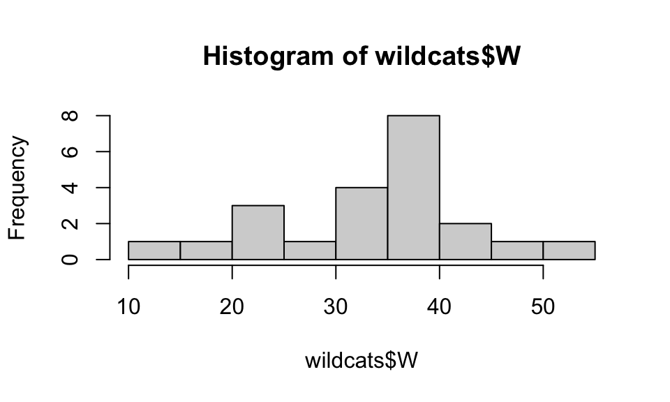

```r
hist(wildcats$W)
```

Presenting our data, we have a responsibility to make it readable, so we can do better than the above. We can supply titles, axis labels, annotations, colors, etc to help us visualize the data in a more useful way.

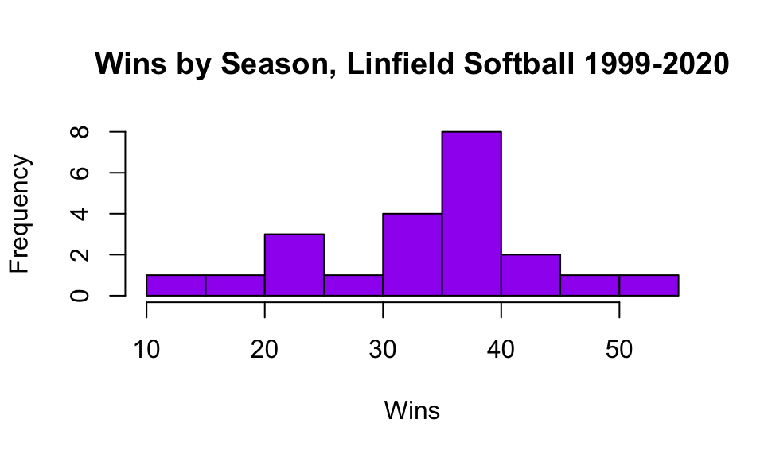

```r
hist(wildcats$W,
     main="Wins by Season, Linfield Softball 1999-2020",
     xlab="Wins",
     col="purple"
     )
```

We can specify the bins in a histogram with the `breaks` option. If we have too few bins for the data, we lose all sorts of information, and if we have too many bins we might have a harder time seeing the shape of the distribution through the noise.

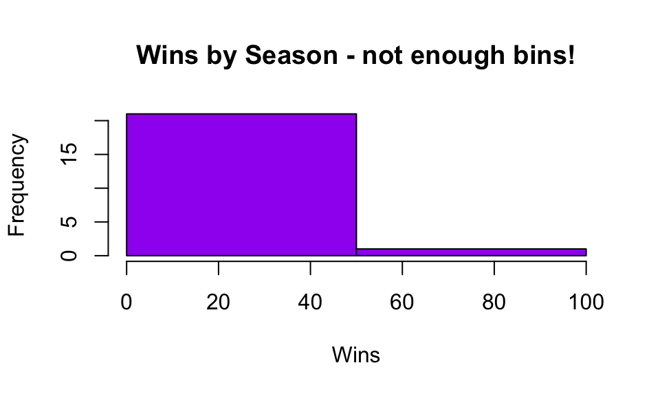

```r
hist(wildcats$W,
     main="Wins by Season - not enough bins!",
     breaks=1,
     xlab="Wins",
     col="purple"
     )
```

## Boxplots

A boxplot is a visual representation of the 5 number summary, and R loves to make them!

Here’s a boxplot in its simplest form.

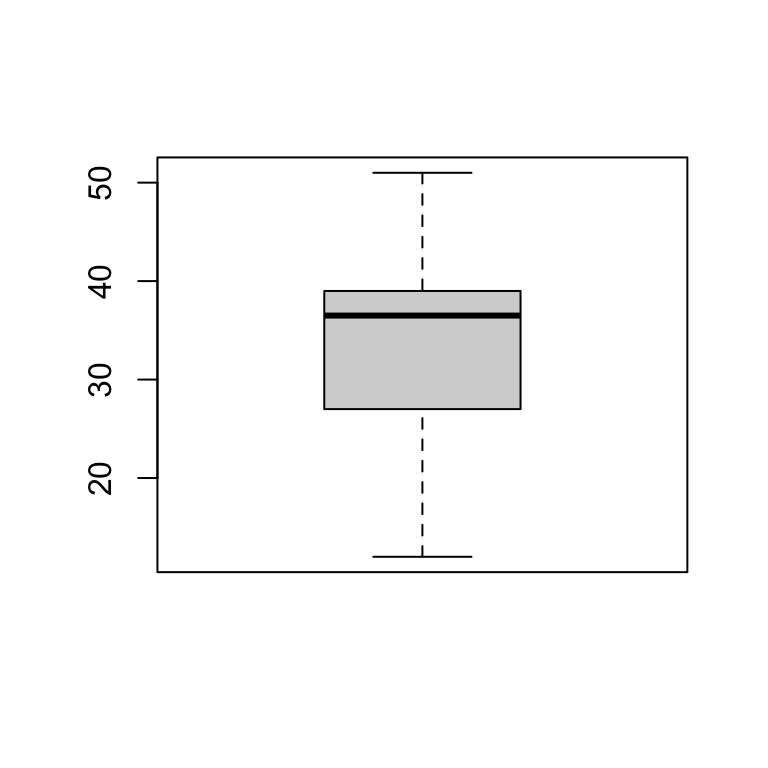

```r
boxplot(wildcats$W)
```

By default a boxplot is presented vertically, but we can ask for a horizontal boxplot as well, and we can add a splash of color.

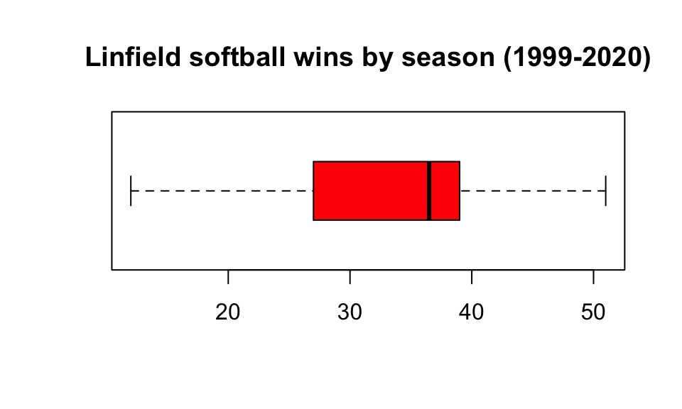

```r
boxplot(wildcats$W,
        main="Linfield softball wins by season (1999-2020)",
        col="red",
        horizontal = TRUE)
```

AND, we can add text to a graph. For instance, we can add the values in the 5 number summary to the boxplot, which gives more precision to the plot!

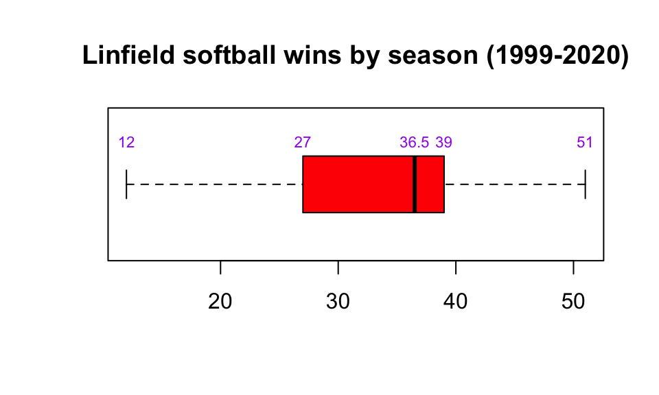

```r
boxplot(wildcats$W,
        main="Linfield softball wins by season (1999-2020)",
        col="red",
        horizontal = TRUE)
v<-fivenum(wildcats$W)
text(x=c(v[1:5]),y=c(rep(1.3,5)),c(v[1:5]),cex=.7,col="purple")
```

## Barplots

For categorical variables it can be useful to make barplots of counts. If we’re considering a vector of values we use the `barplot()` command in conjuntion with the `table()` command

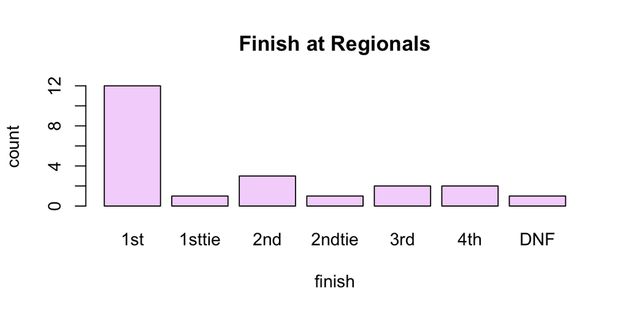

```r
barplot(table(wildcats$District),main="Finish at Regionals",ylab="count",xlab="finish",col="#F5D7FB")
```

## Choosing plot colors

If you type `colors()` at the console prompt you can get a list of names of built in colors.

You can find color codes on-line too, such as the one I used in the barplot code. Here’s one site for this: https://htmlcolorcodes.com/.

## Scatter plots

A scatter plot is a useful way to visualize the relationship between two numeric variables. Here’s a scatter plot in its simplest form.

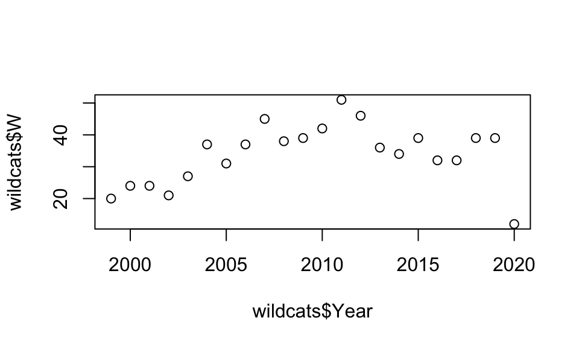

```r
plot(x=wildcats$Year,y=wildcats$W)
```

We can change the shape of points in a plot with the `pch` option, and change the scale of the y-axis.

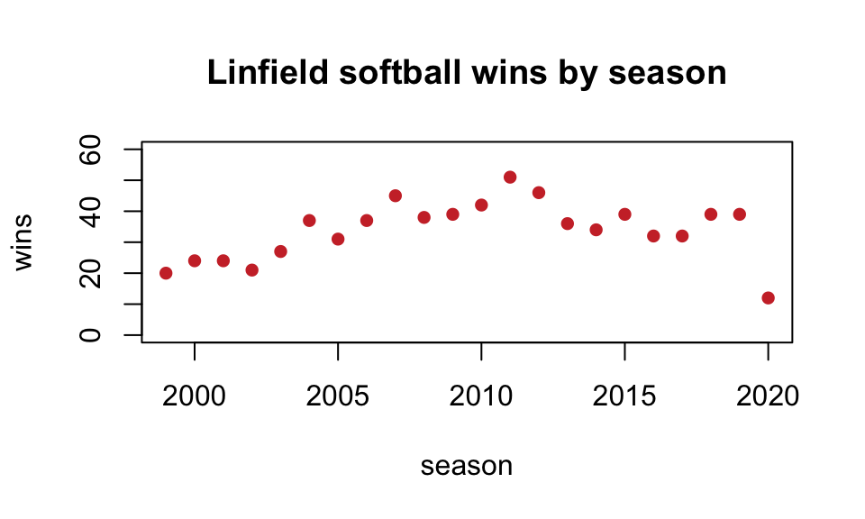

```r
plot(x=wildcats$Year,y=wildcats$W,
     main="Linfield softball wins by season",
     ylab="wins",
     xlab="season",
     col="brown3",
     ylim=c(0,60),
     pch=16)
```

A quick guide to pch and point shapes (google “R pch options” for more details):

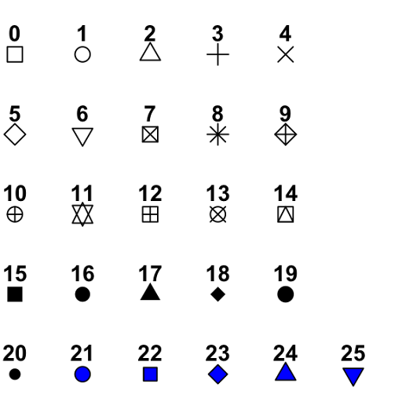

As an aside, we can create a line plot as well, by specifying `type="l"` (that’s an ‘l’ for ‘line’, not the number 1).

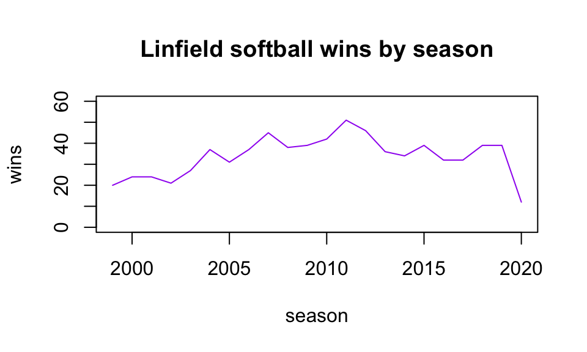

```r
plot(x=wildcats$Year,y=wildcats$W,
     main="Linfield softball wins by season",
     ylab="wins",
     xlab="season",
     col="purple",
     ylim=c(0,60),
     type="l")
```

# More on a Data Matrix

Generally we will work with a data matrix such as the *wildcats* data matrix we imported above, or the *st* data matrix we entered by hand.

In this class we organize a data matrix, aka, data frame, so that **rows are observations, and columns are variables**.

RStudio comes with several built-in data sets. Try entering the following word in the console prompt.

```
faithful
```

What you see displayed is a data frame! What on earth do these numbers mean?

## Extracting information about a data matrix

```r
dim(faithful) # This gives the number of rows (observations) and columns (variables)
```

```
## [1] 272   2
```

This data matrix has 272 rows and 2 columns. What are the variables?

```r
colnames(faithful)
```

```
## [1] "eruptions" "waiting"
```

Click on the Help tab in the lower right pane in Rstudio, and enter *faithful* into the search box (with the hour glass) to get more information about the set. Each row gives information about an eruption of the Old Faithful Geyser. The first variable, `eruptions`, gives the duration of the eruption (in minutes), and the second variable, `waiting`, gives the waiting period (in minutes) until the next eruption.

We can ask for the first 4 rows of the data frame:

```r
head(faithful,4)
```

```
##   eruptions waiting
## 1     3.600      79
## 2     1.800      54
## 3     3.333      74
## 4     2.283      62
```

We can extract the entry in row 6, column 2:

```r
faithful[6,2]
```

```
## [1] 55
```

We can extract the subset of all the data for which the eruption value is at least 5 minutes:

```r
subset(faithful, eruptions >= 5)
```

```
##     eruptions waiting
## 76      5.067      76
## 149     5.100      96
## 151     5.033      77
## 168     5.000      88
```

Only 4 of the 272 eruptions exceeded 5 minutes. One would be lucky to witness such a long eruption. We note that in this `subset()` command we enter the name of the data frame first, then the condition on the variable.

We can extract rows 16 through 25:

```r
faithful[16:25,]
```

```
##    eruptions waiting
## 16     2.167      52
## 17     1.750      62
## 18     4.800      84
## 19     1.600      52
## 20     4.250      79
## 21     1.800      51
## 22     1.750      47
## 23     3.450      78
## 24     3.067      69
## 25     4.533      74
```

We note the comma is necessary. In general, the values before the comma (16-25) specify the row numbers, and the values after the comma specify the column numbers. By leaving the column entry blank, R takes *all* the columns.

> You can type `data()` at the console prompt in RStudio to see a list of all the data sets that come with the program.

## Focusing on a subset of the columns in a data matrix

Returning to the `wildcats` data matrix, suppose we want to focus on just wins and losses by season. We can create a new data frame from the old one that has just these columns:

```r
catWL <- wildcats[c("Year","W","L")]
head(catWL)
```

```
##   Year  W  L
## 1 1999 20 17
## 2 2000 24 10
## 3 2001 24 17
## 4 2002 21 17
## 5 2003 27 11
## 6 2004 37  9
```

## Adding a column to a data matrix

Suppose we want to add a column to the `wildcats` data frame that specifies the total number of games played, something we can do by using columns already present. The following code does this. In one fell swoop we define the column name `GP` and tell R how to build it (wins+losses+ties=games played).

```r
wildcats$GP = wildcats$W+wildcats$L+wildcats$T
```

# Test your understanding

Below are some bits of code. Can you see what information it will provide?

1. What does this code give?

```r
max(wildcats$W)
```

```
## [1] 51
```

ANSWER: The maximum number of wins in a season over this time period.

Which season was this? Here’s a way to extract the entire season (row) from the data matrix that had the most number of wins:

```r
subset(wildcats, W == max(wildcats$W))
```

```
##    Year           Coach  W L T District NCAA GP
## 13 2011 Jackson Vaughan 51 3 0      1st  1st 54
```

Wow! What a season! 51 wins against just 3 losses, first in districts, and National Champions!

2. What does this code give?

```r
table(wildcats$NCAA)
```

```
##
##     1st 2nd 3rd 4th
##  16   2   2   1   1
```

ANSWER: It specifies how well Linfield did at Nationals over the 1999-2020 time period. Linfield has finished 1st twice, 2nd twice, 3rd once, and 4th once. The other 16 seasons they didn’t finish as high as 4th.

3. What does this code give?

```r
sum(wildcats$District=="1st")
```

```
## [1] 12
```

ANSWER: It gives the number of seasons from 1999-2020 in which Linfield was 1st in the District

4. What does this code give?

```r
wildcats$winpct <- wildcats$W/wildcats$GP
```

ANSWER: It creates a new column in the data frame wildcats called `winpct`. This column records the winning percentage for the team each season (wins divided by games played).

5. What does this code give?

```r
max(wildcats$winpct)
```

```
## [1] 0.9444444
```

ANSWER: It returns the best winning percentage for a season between 1999 and 2020.

Which season was this?

```r
subset(wildcats, winpct == max(wildcats$winpct))
```

```
##    Year           Coach  W L T District NCAA GP    winpct
## 13 2011 Jackson Vaughan 51 3 0      1st  1st 54 0.9444444
```

Not surprisingly, the best winning percentage occurred in the magical 2011 season in which the team went 51-3.

6. What does this code give?

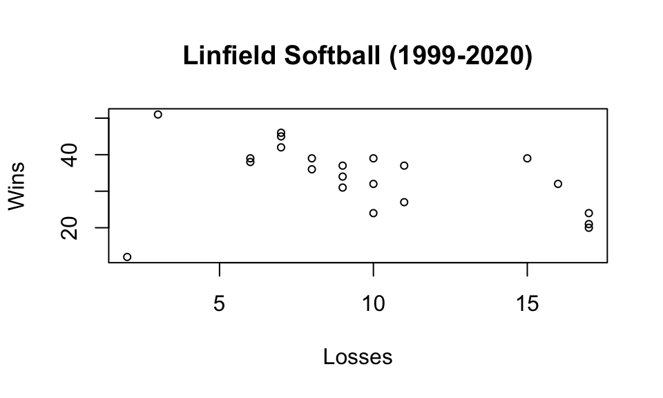

```r
plot(x=wildcats$L, y=wildcats$W,cex=.7,
     main="Linfield Softball (1999-2020)",
     xlab="Losses",
     ylab="Wins")
```

ANSWER: Scatterplot of wins vs losses. This plot makes it clear that 2020 was a strange season (the point in the lower left corner). This visual deviation from the trend indicates that something “different” was going on. What was it? (global pandemic!)

7. What does this code give?

```r
fivenum(wildcats$W[wildcats$Coach=="Jackson Vaughan"])
```

```
## [1] 12 32 37 39 51
```

ANSWER: This code gives the 5 number summary for the Linfield softball wins for just the seasons in the data set in which the coach was Jackson Vaughan. More generally, consider this code, which makes use of the `aggregate()` method:

```r
aggregate(wildcats$W, by=list(wildcats$Coach), FUN = median)
```

```
##           Group.1  x
## 1 Jackson Vaughan 37
## 2     Laura Kenow 24
```

The `aggregate()` method executes a function on a variable that has been grouped by a categorical variable. In the code above we have chosen to determine the median number of wins for each coach over this time period.